# Simple linear regresssion

## Performing Linear Regression

```r
lm(formula = height ~ weight,
   data = sample)
```

```
Call:
lm(formula = height ~ weight, data = sample)

Coefficients:
(Intercept)       weight
   102.1758       0.9336
```

b0 = 102.17 b1 = 0.93

If I change weight by +1, how does height change?

-> 0.9336

height = 102 + (0.9336 * weight) diff_height = 0.9336 * diff_weight

What would be the height of someone weighs 60kg?

```r
102 + (0.9336 * 60)
```

```
[1] 158.016
```

## The Patsy Notation (to be continued!)

y ~ x

~: “varies with”

## Better ways of using the model

```r
model <- lm(formula = height ~ weight,
   data = sample))
```

[output not shown]

```r
model$coefficients
```

```
(Intercept)      weight
102.1757773   0.9335503
```

```r
fitted(model)
```

```
       1        2        3        4        5        6        7        8        9       10
178.7269 162.8565 181.5276 173.1256 186.1953 188.0624 165.6572 179.6605 189.9295 171.2585
```

using the `predict()` function

```r
predict_at <- data.frame(weight = c(60, 70, 78))

predict(model, newdata = predict_at)
```

```
       1        2        3
158.1888 167.5243 174.9927
```

Based on our current model of height, we expect a person weighing 60kg will measure around 160cm.

```r
library(modelr)
```

`{modelr}`

`add_residuals()` `add_predictions()`

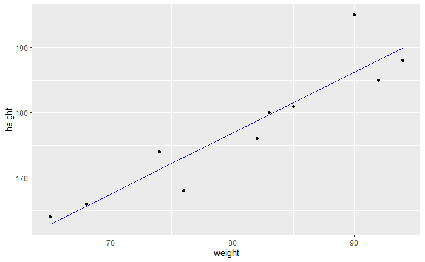

What about predicting values not in our data (unobserved weights)

| weight | pred |
| --- | --- |
| 40 | 139.5178 |
| 41 | 140.4513 |
| 42 | 141.3849 |
| 43 | 142.3184 |
| 44 | 143.2520 |
| 45 | 144.1855 |
| 46 | 145.1191 |
| 47 | 146.0526 |
| 48 | 146.9862 |
| 49 | 147.9197 |

[output cut: 71 more lines]